# Experiment No 1

[figure not shown]

### Experiment No. 01

[figure not shown]

**AIM**

**To perform and analyze basic image arithmetic operations (addition, subtraction, difference, multiplication, division) on digital images**

**Theory/Procedure/Algorithm**

Image arithmetic operations involve basic mathematical manipulations applied to digital images to enhance or analyze their content. These operations are fundamental in image processing and have various applications

```python
import numpy as np
import cv2
import matplotlib.pyplot as plt
```

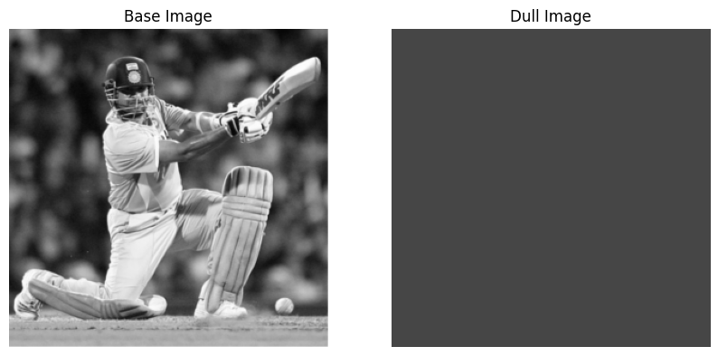

```
Base shape: (300, 300, 3)
Dull shape: (300, 300, 3)
```

```python
base = cv2.imread('base.png')
dull = cv2.imread('dull.png')


if base.shape != dull.shape:
    print("Resizing the images to the same size...")
    dull = cv2.resize(dull, (base.shape[1], dull.shape[0]))

fig, axes = plt.subplots(1, 2, figsize=(10, 5))
axes[0].imshow(base)
axes[0].set_title("Base Image")
axes[0].axis('off')

axes[1].imshow(dull)
axes[1].set_title("Dull Image")
axes[1].axis('off')

plt.show()


print("Base shape:", base.shape)
print("Dull shape:", dull.shape)
```

1. **Addition**: This operation combines pixel values from two images, effectively brightening the result. For each pixel, the values are summed, potentially increasing contrast. Care must be taken to handle overflow, where pixel values exceed the maximum allowed intensity.

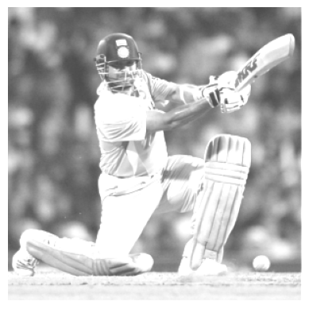

```python
add_image = cv2.add(base, dull)

plt.imshow(add_image)
plt.axis('off')
plt.show()
```

2. **Subtraction**: Subtraction computes the difference between corresponding pixel values of two images. This operation is useful for highlighting changes or differences, such as in background subtraction or anomaly detection. Handling negative values is crucial, as they may need to be clipped or normalized.

[figure not shown]

```python
subtract_image = cv2.subtract(base, dull)

plt.imshow(subtract_image)
plt.axis('off')
plt.show()
```

3. **Absolute Difference**: The absolute difference operation calculates the absolute value of the pixel-wise differences between two images. This method helps in detecting variations and discrepancies without introducing negative values, making it useful for comparative analysis.

[figure not shown]

```python
absolute_difference_image = cv2.absdiff(base, dull)

plt.imshow(absolute_difference_image)
plt.axis('off')
plt.show()
```

4. **Multiplication**: Multiplying an image by a scalar or another image scales the pixel values, adjusting brightness and contrast. This operation can enhance features or apply filters. Extreme multipliers may cause pixel saturation, which can lead to loss of detail or distortion.

[figure not shown]

```python
multiply_image = cv2.multiply(base, dull)

plt.imshow(multiply_image)
plt.axis('on')
plt.show()
```

5. **Division**: This operation divides the pixel values of one image by those of another, or by a scalar, to normalize or adjust contrast. It is essential to avoid division by zero, which can create artifacts or undefined values.

[figure not shown]

```python
divide_image = cv2.divide(base, dull)

plt.imshow(divide_image)
plt.axis('off')
plt.show()
```

**CONCLUSION**

In this experiment, we explored basic image arithmetic operations: addition, subtraction, multiplication, division, and absolute difference. Addition can brighten images but may lead to overflow. Subtraction highlights differences, though negative values need careful management. Multiplication adjusts brightness and contrast, with a risk of saturation. Division normalizes contrast but requires avoiding division by zero. Absolute difference reveals pixel-wise variations without negative values. Each operation serves specific purposes and demands careful handling to ensure image quality.

**ASSESSMENT**

[figure not shown]